# Midterm 2

Brian Roepke

November 22, 2020

# YouTube Video Data Analysis

Import all libraries needed.

```r
# Basic libraries
library(ggplot2)
library(dplyr)
library(tidyverse)
library(corrplot)
library(ggcorrplot)
library(lubridate)
library(jsonlite)
library(stringi)
library(wesanderson)

# Text mining libs
library(SnowballC)
library(tidytext)
library(spacyr)
library(tm)
library(ggraph)
library(textstem)
library(ggridges)
```

# Import, Cleaning, EDA

```r
# Read in the Data from a CSV file.
df <- read.csv("YouTube-videos.csv") # colClasses=c("headline"="character")
```

```r
# Remove unwanted columns
df$thumbnail_link <- NULL
df$comments_disabled <- NULL
df$video_error_or_removed <- NULL
df$ratings_disabled <- NULL

# Convert Dates
df$trending_date <- as.Date(df$trending_date, "%y.%d.%m")
df$publish_time <- as.Date(df$publish_time, "%Y-%m-%d")

# Change Others to Factors
df$category_id <- as.factor(df$category_id)
```

## Mapping Category ID to an Actual Category English Name

We can read in the separate JSON file and join them to our DataFrame

```r
# Import the YouTube Category Names
cats <- fromJSON("youtubeVideoCatUS.json", flatten = TRUE)
cats <- as.data.frame(cats)
```

```r
# Create a new column that contains the English name of the category based on the Category ID
df$category_name <- cats$items.snippet.title[match(df$category_id, cats$items.id)]
df$category_name <- as.factor(df$category_name)
```

## Cleaning the Data

There is one anomaly in the data where a number of entries for video_id have `#NAME?` as a value. This will cause user counts and uniqueness counts to be off. We can set these values to a randomly generated string that appears similar to a valid YouTube ID.

```r
df %>%
  filter(video_id == "#NAME?") %>%
  summarize(total_records = n())
```

| total_records |
| --- |
| 525 |

Replace each occurrence of #NAME? with a random generated string.

```r
replacements_made <- 0

for (row in 1:nrow(df)) {
  if (df$video_id[row] == "#NAME?") {
    df$video_id[row] <- stri_rand_strings(1, 11)
    replacements_made <- replacements_made + 1
  }
}

replacements_made
```

```
## [1] 525
```

**NOTE**: There were `525` entries of `#NAME?` prior, and `525` replacements were made.

```r
df$video_id <- as.factor(df$video_id)
```

## EDA

Perform Exploratory Data Analysis to better understand the data.

### Structure & Summary Statistics

```r
str(df)
```

```
## 'data.frame':    40881 obs. of  13 variables:
##  $ video_id     : Factor w/ 24628 levels "__4c1JCHvaQ",..: 14525 587 2773 6811 1616 855 321 1484 12171 2121 ...
##  $ trending_date: Date, format: "2017-11-14" "2017-11-14" ...
##  $ title        : chr  "Eminem - Walk On Water (Audio) ft. Beyoncé" "PLUSH - Bad Unboxing Fan Mail" "Racist Superman | Rudy Mancuso, King Bach & Lele Pons" "I Dare You: GOING BALD!?" ...
##  $ channel_title: chr  "EminemVEVO" "iDubbbzTV" "Rudy Mancuso" "nigahiga" ...
##  $ category_id  : Factor w/ 17 levels "1","2","10","15",..: 3 9 9 10 3 11 9 8 10 8 ...
##  $ publish_time : Date, format: "2017-11-10" "2017-11-13" ...
##  $ tags         : chr  "Eminem|\"Walk\"|\"On\"|\"Water\"|\"Aftermath/Shady/Interscope\"|\"Rap\"" "plush|\"bad unboxing\"|\"unboxing\"|\"fan mail\"|\"idubbbztv\"|\"idubbbztv2\"|\"things\"|\"best\"|\"packages\"|"| __truncated__ "racist superman|\"rudy\"|\"mancuso\"|\"king\"|\"bach\"|\"racist\"|\"su…
##  $ views        : int  17158579 1014651 3191434 2095828 33523622 1309699 2987945 748374 4477587 505161 ...
##  $ likes        : int  787425 127794 146035 132239 1634130 103755 187464 57534 292837 4135 ...
##  $ dislikes     : int  43420 1688 5339 1989 21082 4613 9850 2967 4123 976 ...
##  $ comment_count: int  125882 13030 8181 17518 85067 12143 26629 15959 36391 1484 ...
##  $ description  : chr  "Eminem's new track Walk on Water ft. Beyoncé is available everywhere: http://shady.sr/WOWEminem \\nPlaylist Bes"| __truncated__ "STill got a lot of packages. Probably will last for another year. On a side note, more 2nd channel vids soon. e"| __truncated__ "WATCH MY PREVIO…
##  $ category_name: Factor w/ 17 levels "Autos & Vehicles",..: 9 2 2 4 9 10 2 12 4 12 ...
```

```r
df %>%
  select(video_id, trending_date, publish_time, views, likes, dislikes, comment_count, category_name) %>%
  summary()
```

```
##         video_id     trending_date         publish_time
##  6ZfuNTqbHE8:    8   Min.   :2017-11-14   Min.   :2008-01-13
##  l_lblj8Cq0o:    8   1st Qu.:2018-01-04   1st Qu.:2018-01-02
##  UceaB4D0jpo:    8   Median :2018-02-26   Median :2018-02-24
##  VYOjWnS4cMY:    8   Mean   :2018-02-27   Mean   :2018-02-23
##  7X_WvGAhMlQ:    7   3rd Qu.:2018-04-24   3rd Qu.:2018-04-23
##  9v_rtaye2yY:    7   Max.   :2018-06-14   Max.   :2018-06-14
##  (Other)    :40835
##      views               likes            dislikes       comment_count
##  Min.   :      733   Min.   :      0   Min.   :      0   Min.   :      0
##  1st Qu.:   143902   1st Qu.:   2191   1st Qu.:     99   1st Qu.:    417
##  Median :   371204   Median :   8780   Median :    303   Median :   1301
##  Mean   :  1147036   Mean   :  39583   Mean   :   2009   Mean   :   5043
##  3rd Qu.:   963302   3rd Qu.:  28717   3rd Qu.:    950   3rd Qu.:   3713
##  Max.   :137843120   Max.   :5053338   Max.   :1602383   Max.   :1114800
##
##          category_name
##  Entertainment  :13451
##  News & Politics: 4159
##  People & Blogs : 4105
##  Comedy         : 3773
##  Music          : 3731
##  Sports         : 2787
##  (Other)        : 8875
```

```r
head(df)
```

|  | video_id | trending_date | title | channel_title | category_id | publish_time | tags | views | likes | dislikes | comment_count | description | category_name |
| --- | --- | --- | --- | --- | --- | --- | --- | --- | --- | --- | --- | --- | --- |
| 1 | n1WpP7iowLc | 2017-11-14 | Eminem - Walk On Water (Audio) ft. Beyoncé | EminemVEVO | 10 | 2017-11-10 | Eminem\|"Walk"\|"On"\|"Water"\|"Aftermath/Shady/Interscope"\|"Rap" | 17158579 | 787425 | 43420 | 125882 | Eminem's new track Walk on Water ft. Beyoncé is available everywhere: http://shady.sr/WOWEminem \\nPlaylist Best of Eminem: https://goo.gl/AquNpo\\nSubscribe for more: https://goo.gl/DxCrDV\\n\\nFor m… | Music |
| 2 | 0dBIkQ4Mz1M | 2017-11-14 | PLUSH - Bad Unboxing Fan Mail | iDubbbzTV | 23 | 2017-11-13 | plush\|"bad unboxing"\|"unboxing"\|"fan mail"\|"idubbbztv"\|"idubbbztv2"\|"things"\|"best"\|"packages"\|"plushies"\|"chontent chop" | 1014651 | 127794 | 1688 | 13030 | STill got a lot of packages. Probably will last for another year. On a side note, more 2nd channel vids soon. editing with premiere from now on, gon' be a tedious transition, but i think it's for the … | Comedy |
| 3 | 5qpjK5DgCt4 | 2017-11-14 | Racist Superman \| Rudy Mancuso, King Bach & Lele Pons | Rudy Mancuso | 23 | 2017-11-12 | racist superman\|"rudy"\|"mancuso"\|"king"\|"bach"\|"racist"\|"superman"\|"love"\|"rudy mancuso poo bear black white official music video"\|"iphone x by pineapple"\|"lelepons"\|"hannahstocking"\|"rudy… | 3191434 | 146035 | 5339 | 8181 | WATCH MY PREVIOUS VIDEO ▶ \\n\\nSUBSCRIBE ► https://www.youtube.com/channel/UC5jkXpfnBhlDjqh0ir5FsIQ?sub_confirmation=1\\n\\nTHANKS FOR WATCHING! LIKE & SUBSCRIBE FOR MORE VIDEOS!\\n------------------… | Comedy |
| 4 | d380meD0W0M | 2017-11-14 | I Dare You: GOING BALD!? | nigahiga | 24 | 2017-11-12 | ryan\|"higa"\|"higatv"\|"nigahiga"\|"i dare you"\|"idy"\|"rhpc"\|"dares"\|"no truth"\|"comments"\|"comedy"\|"funny"\|"stupid"\|"fail" | 2095828 | 132239 | 1989 | 17518 | I know it's been a while since we did this show, but we're back with what might be the best episode yet!\\nLeave your dares in the comment section! \\n\\nOrder my book how to write good \\nhttp://higa… | Entertainment |
| 5 | 2Vv-BfVoq4g | 2017-11-14 | Ed Sheeran - Perfect (Official Music Video) | Ed Sheeran | 10 | 2017-11-09 | edsheeran\|"ed sheeran"\|"acoustic"\|"live"\|"cover"\|"official"\|"remix"\|"official video"\|"lyrics"\|"session" | 33523622 | 1634130 | 21082 | 85067 | \U0001f3a7: https://ad.gt/yt-perfect\\n\U0001f4b0: https://atlanti.cr/yt-album\\nSubscribe to Ed's channel: http://bit.ly/SubscribeToEdSheeran\\n\\nFollow Ed on...\\nFacebook: http://www.facebook.com/… | Music |
| 6 | 0yIWz1XEeyc | 2017-11-14 | Jake Paul Says Alissa Violet CHEATED with LOGAN PAUL! #DramaAlert Team 10 vs Martinez Twins! | DramaAlert | 25 | 2017-11-13 | #DramaAlert\|"Drama"\|"Alert"\|"DramaAlert"\|"keemstar"\|"youtube news"\|"jake paul"\|"team 10"\|"alissa violet"\|"cheated"\|"logan paul"\|"logan paul alissa violet"\|"jake paul alissa violet"\|"Marti… | 1309699 | 103755 | 4613 | 12143 | ► Follow for News! - https://twitter.com/KEEMSTAR\\n\\n► Also follow #DramaAlert on:\\n⋆ Instagram: https://instagram.com/DramaAlert\\n⋆ Twitter: https://twitter.com/DramaAlert\\n⋆ Facebook: https://f… | News & Politics |

```r
tail(df)
```

|  | video_id | trending_date | title | channel_title | category_id | publish_time | tags | views | likes | dislikes | comment_count | description | category_name |
| --- | --- | --- | --- | --- | --- | --- | --- | --- | --- | --- | --- | --- | --- |
| 40876 | 7E1np354AEc | 2018-06-14 | Вечер с Владимиром Соловьевым от 13.06.2018 | Россия 24 | 24 | 2018-06-13 | поединок\|"михеев"\|"полный контакт"\|"вечер с владимиром соловьевым"\|"ковтун"\|"жириновский"\|"сатановский"\|"соловьев"\|"вечер"\|"владимир соловьев" | 201847 | 1568 | 407 | 537 | Вечер с Владимиром Соловьевым от 13.06.2018\nПодпишитесь на канал: https://www.youtube.com/c/poedinoktv?sub_confirmation=1\n\nОфициальный канал ток-шоу на общественно-политические темы: Воскресный веч… | Entertainment |
| 40877 | sGolxsMSGfQ | 2018-06-14 | HOW2: How to Solve a Mystery | Annoying Orange | 24 | 2018-06-13 | annoying orange\|"funny"\|"fruit"\|"talking"\|"animation"\|"daneboe"\|"The Annoying Orange"\|"how2"\|"cartoon"\|"comedy"\|"satire"\|"parody"\|"spoof"\|"lampoon"\|"silly"\|"how2 how to solve a mystery"… | 80685 | 1701 | 99 | 1312 | \U0001f6a8 NEW MERCH! http://amzn.to/annoyingorange \U0001f6a8➤ Watch more ▸ https://bit.ly/2Mhjgqc➤ AO GAMING CHANNEL! ▸ http://bit.ly/AOGaming➤ Don't be an apple! Subscribe! It's FREE! ▸ http://bit.… | Entertainment |
| 40878 | 8HNuRNi8t70 | 2018-06-14 | Eli Lik Lik Episode 13 Partie 01 | Elhiwar Ettounsi | 24 | 2018-06-13 | hkayet tounsia\|"elhiwar ettounsi"\|"denya okhra"\|"oumour jedia"\|"andi mankolek"\|"تاج الحاضرة"\|"oumour jeddya"\|"karim el gharbi"\|"dari deco"\|"360 degrees"\|"klem ennes"\|"ma binetna"\|"liman ya… | 103339 | 460 | 66 | 51 | ► Retrouvez vos programmes préférés : https://goo.gl/gxtCTu► Abonnez-vous à la chaîne : https://goo.gl/v5Nz1p► Rejoignez-nous sur Facebook: https://goo.gl/sfjrWb► Abonnez-vous sur instagram : https://… | Entertainment |
| 40879 | GWlKEM3m2EE | 2018-06-14 | KINGDOM HEARTS III – SQUARE ENIX E3 SHOWCASE 2018 Trailer | Kingdom Hearts | 20 | 2018-06-11 | Kingdom Hearts\|"KH3"\|"Kingdom Hearts 3"\|"Frozen"\|"Square Enix"\|"Microsoft"\|"Nomura Tetsuya"\|"Anna"\|"Elsa"\|"Olaf"\|"JRPG"\|"Kristoff"\|"Aqua"\|"Sora"\|"Square Enix E3"\|"E3 2018"\|"Digital Sho… | 773347 | 25900 | 224 | 3881 | Find out more about Kingdom Hearts 3: https://sqex.link/kingd5303cThe light is gathering together Hearts driven by one oath, one purpose.Originally aired at the SQUARE ENIX E3 2018 Showcase.On their q… | Gaming |
| 40880 | lbMKLzQ4cNQ | 2018-06-14 | Trump Advisor Grovels To Trudeau | The Young Turks | 25 | 2018-06-13 | 180612__TB02SorryExcuse\|"News"\|"Politics"\|"The Young Turks"\|"Ana Kasparian"\|"Brett Erlich"\|"Mark Thompson"\|"TYT"\|"progressive"\|"liberal"\|"justin trudeau"\|"peter navarro"\|"trudeau"\|"donald… | 115225 | 2115 | 182 | 1672 | Peter Navarro isn’t talking so tough now. Ana Kasparian, Brett Erlich, Mark Thompson, the hosts of The Young Turks, break it down. TYT now has a full audio network! Available where you listen to podca… | News & Politics |
| 40881 | POTgw38-m58 | 2018-06-14 | 【完整版】遇到恐怖情人該怎麼辦？2018.06.13小明星大跟班 | 我愛小明星大跟班 | 24 | 2018-06-13 | 吳宗憲\|"吳姍儒"\|"小明星大跟班"\|"Sandy"\|"Jacky wu"\|"憲哥"\|"中天綜合台"\|"CH36"\|"中天電視台"\|"我愛小明星大跟班"\|"藝人"\|"來賓"\|"李妍瑾"\|"玉兔"\|"班傑"\|"LaLa"\|"小優"\|"少少"\|"專家"\|"陳筱屏"\|"律師"\|"Wendy"\|"心理師"\|"羅友志"\|"社會記者"\|"暴力"\|"男友"\|… | 107392 | 300 | 62 | 251 | 藝人：李妍瑾、玉兔、班傑、LaLa、小優、少少專家：陳筱屏(律師)、Wendy(心理師)、羅友志(社會記者)「未經著作權人事先書面同意，勿將內容用於商業性質之分享、連結。」「如有任何營業使用，必須事先取得書面同意」● 電視播出／週一至週五 晚間10點 中天綜合台CH36頻道● 影音平台／每晚2400準時放送 YouTube 搜尋《我愛小明星大跟班》▶按讚《小明星大跟班》https://www.fa… | Entertainment |

## Views, Likes and Dislikes

Analyze the number of views, likes, and dislikes with full data visualization (univariate and multivariate). Then comment on various trends.

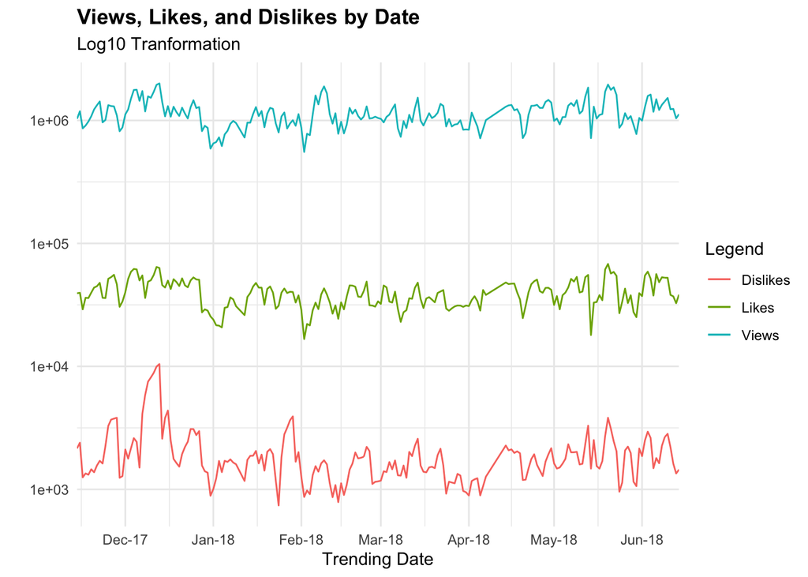

```r
colors <- c("Views" = "#00BFC4", "Likes" = "#7CAE00", "Dislikes" = "#F8766D")

df %>%
  # mutate(mon = floor_date(trending_date, 'month')) %>%
  mutate(mon = trending_date) %>%
  group_by(mon) %>%
  summarize(dislikes = mean(dislikes), likes = mean(likes), views = mean(views), .groups = "keep") %>%
  ggplot(aes(x = mon)) +
  geom_line(aes(y = views, color = "Views")) +
  geom_line(aes(y = likes, color = "Likes")) +
  geom_line(aes(y = dislikes, color = "Dislikes")) +
  scale_x_date(date_breaks = "1 month", expand = c(0, 0), date_labels = "%b-%y") +
  scale_y_continuous(trans = "log10") +
  theme_minimal() +
  theme(
    plot.title = element_text(face = "bold")
  ) +
  labs(
    x = "Trending Date", y = "",
    title = "Views, Likes, and Dislikes by Date",
    subtitle = "Log10 Tranformation",
    color = "Legend"
  ) +
  scale_color_manual(values = colors)
```

Other than the various difference in quantities of the three, they tend to remain fairly consistent over time when transformed on a logarithmic scale. With dislikes, we see a noticeable order of magnitude shift in the early part of December.

### Views

We’ll start by examining Views.

[figure not shown]

```r
df %>%
  ggplot(aes(x = views)) +
  geom_histogram(color = "lightblue3", fill = "lightblue", bins = 30) +
  scale_y_continuous(trans = "log10") +
  theme_minimal() +
  theme(
    plot.title = element_text(face = "bold")
  ) +
  labs(
    x = NULL, y = "Count (Log 10)",
    title = "Distribution of Views",
    subtitle = "Using a log10 transformation the x-axis"
  )
```

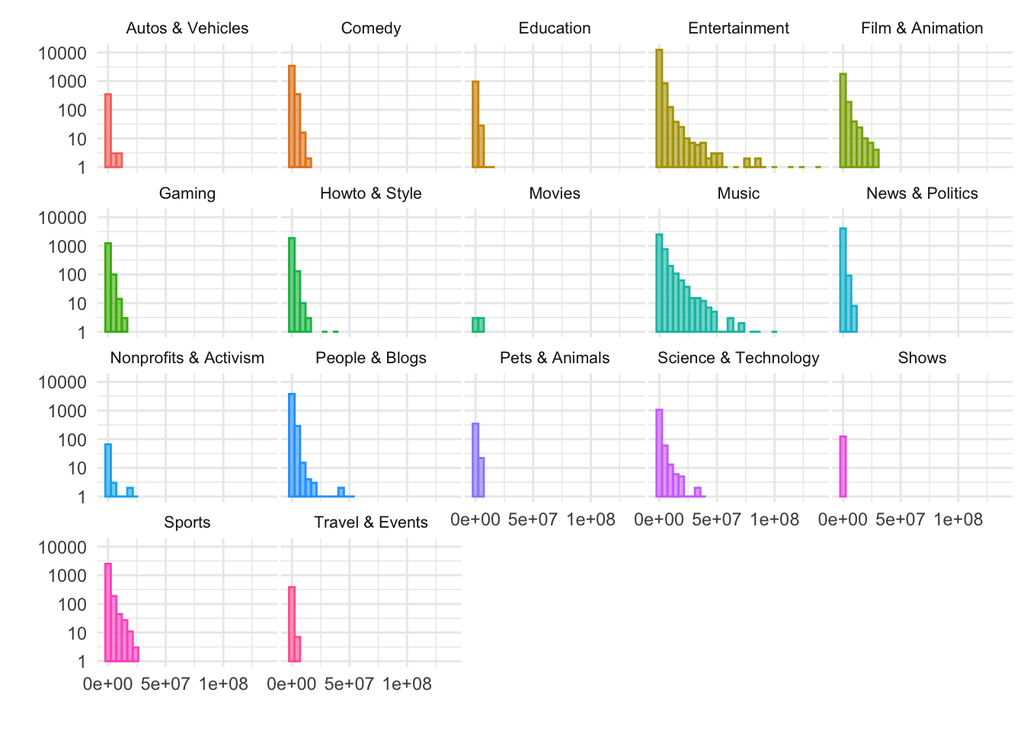

```r
df %>%
  ggplot(aes(x = views, color = category_name, fill = category_name)) +
  geom_histogram(alpha = 0.6, bins = 30) +
  scale_y_continuous(trans = "log10") +
  theme_minimal() +
  theme(
    legend.position = "none",
    panel.spacing = unit(0.1, "lines"),
    strip.text.x = element_text(size = 8)
  ) +
  xlab("") +
  ylab("") +
  facet_wrap(~category_name)
```

When breaking out each category, we can see that the distributions generally have the same shape as the population. However, the relative concentration of each category. *Entertainment* is the standout leader in view volume, *Comedy*, *News & Politics*, *People & Blogs*, and *Music* also have significant numbers.

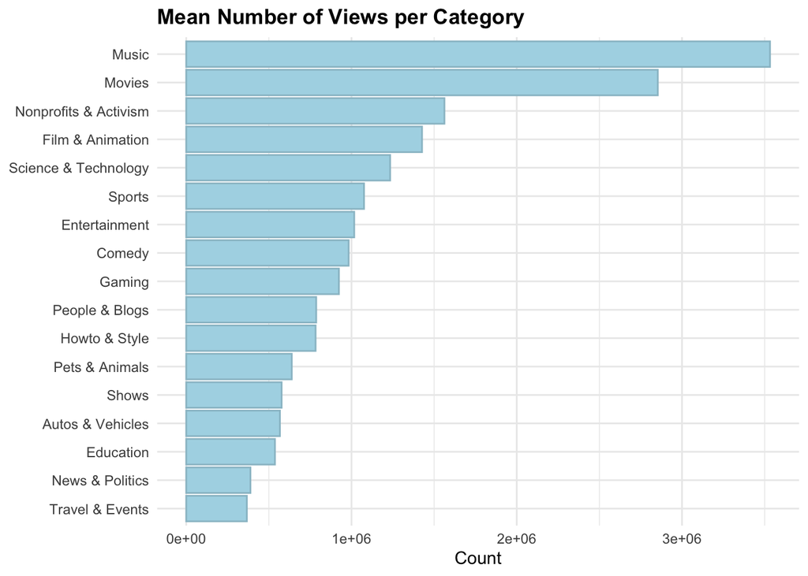

```r
df %>%
  group_by(category_name) %>%
  summarise(total_views = mean(views), .groups = "keep") %>%
  arrange(desc(total_views)) %>%
  ggplot(aes(reorder(category_name, total_views), total_views)) +
  geom_col(color = "lightblue3", fill = "lightblue") +
  theme_minimal() +
  theme(
    plot.title = element_text(face = "bold")
  ) +
  labs(
    x = NULL, y = "Count",
    title = "Mean Number of Views per Category"
  ) +
  coord_flip()
```

When we look at the mean views versus the distribution of views, different categories after *Music* end up higher on the list. *Movies*, *Nonprofit & Activism*, *Film & Animation* all have a minimal overall share of views, but a very high mean number of views.

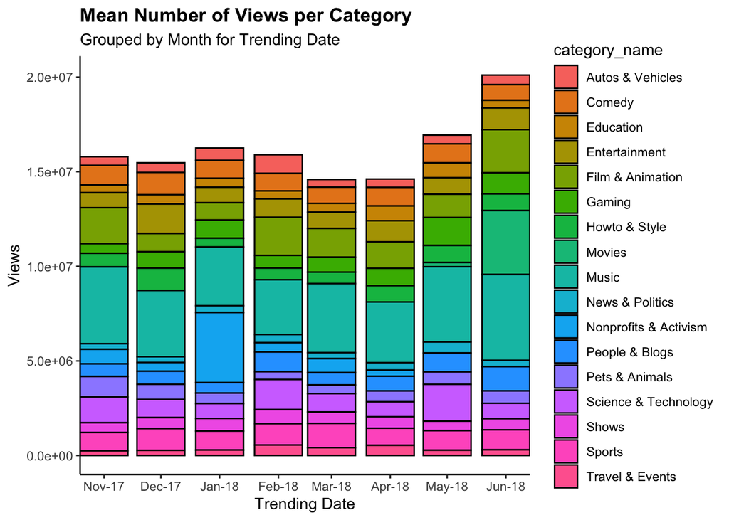

```r
df %>%
  mutate(mon = floor_date(trending_date, "month")) %>%
  group_by(mon, category_name) %>%
  summarize(total = mean(views), .groups = "keep") %>%
  ggplot(aes(x = mon, y = total, fill = category_name)) +
  geom_col(color = "black") +
  scale_x_date(date_breaks = "1 month", expand = c(0, 0), date_labels = "%b-%y") +
  theme_classic() +
  theme(
    plot.title = element_text(face = "bold")
  ) +
  labs(
    x = "Trending Date", y = "Views",
    title = "Mean Number of Views per Category",
    subtitle = "Grouped by Month for Trending Date"
  )
```

Here we see how mean views trend over time, based on their*trending date*, not original publish date. We can see a slight directional increase in views in later dates. For the most part, categories appear to remain fairly consistent over time relative to each other; we can see a stand-out in January where the *Nonprofit & Activism* category shows a one-month increase. A similar increase in *Movies* in June 2018, potentially signaling the release of a new film or trailer. We can examine that.

```r
df %>%
  filter(category_name == "Movies" & trending_date > 2018-06-01) %>%
  group_by(video_id, title) %>%
  summarise(total_views = sum(views)) %>%
  arrange(desc(total_views))
```

| video_id | title | total_views |
| --- | --- | --- |
| l7E0kTvARsA | Golak Bugni Bank Te Batua Full Movie (HD) \| Harish Verma \| Simi Chahal \| Superhit Punjabi Movies | 17120490 |

Turns out that it is a single video *Golak Bugni Bank Te Batua Full Movie (HD) | Harish Verma | Simi Chahal | Superhit Punjabi Movies* that was trending and produced `17,120,490` views total

### Likes

Next we’ll explore Likes.

[figure not shown]

```r
df %>%
  ggplot(aes(x = likes)) +
  geom_histogram(color = "green4", fill = "palegreen2", bins = 30) +
  geom_vline(xintercept = median(df$likes), lwd = 0.5, linetype = "dashed") +
  geom_vline(xintercept = mean(df$likes), lwd = 0.5) +
  scale_y_continuous(trans = "log10") +
  theme_minimal() +
  theme(
    plot.title = element_text(face = "bold")
  ) +
  labs(
    x = NULL, y = "Count (Log 10)",
    title = "Distribution of Likes",
    subtitle = "Using a log10 transformation the x-axis"
  )
```

```r
sprintf("Skewness = %s", moments::skewness(df$likes))
```

```
## [1] "Skewness = 13.6567929877601"
```

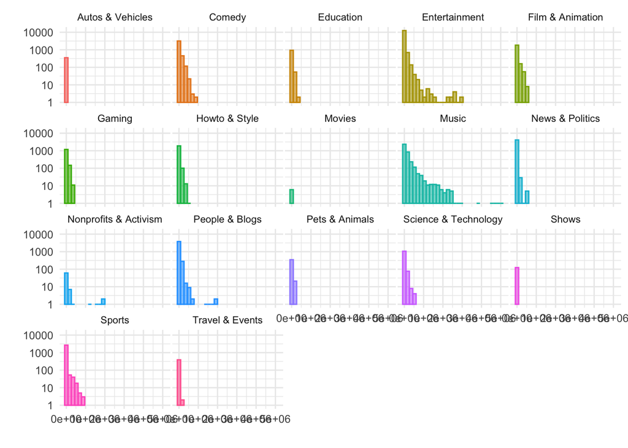

```r
df %>%
  ggplot(aes(x = likes, color = category_name, fill = category_name)) +
  geom_histogram(alpha = 0.6, bins = 30) +
  scale_y_continuous(trans = "log10") +
  theme_minimal() +
  theme(
    legend.position = "none",
    panel.spacing = unit(0.1, "lines"),
    strip.text.x = element_text(size = 8)
  ) +
  xlab("") +
  ylab("") +
  facet_wrap(~category_name)
```

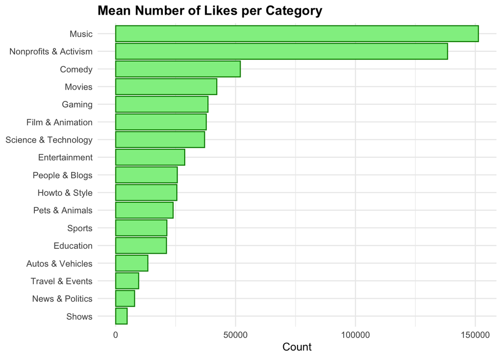

```r
df %>%
  group_by(category_name) %>%
  summarise(total_likes = mean(likes), .groups = "keep") %>%
  arrange(desc(total_likes)) %>%
  ggplot(aes(reorder(category_name, total_likes), total_likes)) +
  geom_col(color = "green4", fill = "palegreen2") +
  theme_minimal() +
  theme(
    plot.title = element_text(face = "bold")
  ) +
  labs(
    x = NULL, y = "Count",
    title = "Mean Number of Likes per Category"
  ) +
  coord_flip()
```

Similar to the results of the overall Views for the categories, different categories have a greater mean number of Likes. *Music* is the first, and *Nonprofits & Activism* a close second. This suggests that while the number of videos in these categories is smaller, the *likes* activity is greater per video.

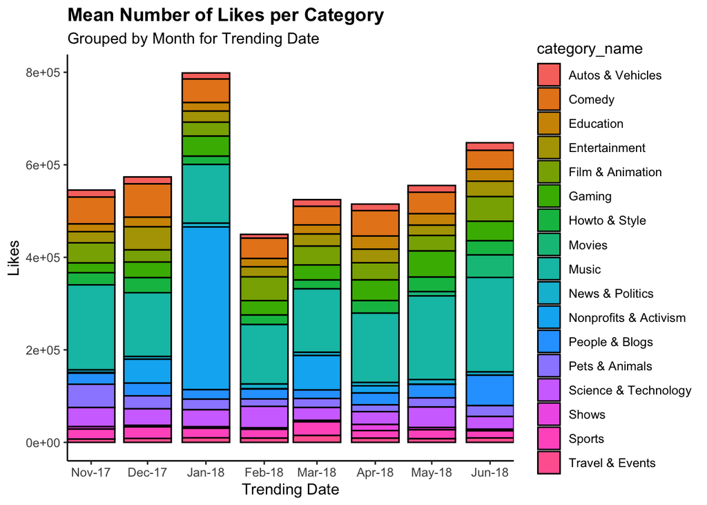

```r
df %>%
  mutate(mon = floor_date(trending_date, "month")) %>%
  group_by(mon, category_name) %>%
  summarize(total = mean(likes), .groups = "keep") %>%
  ggplot(aes(x = mon, y = total, fill = category_name)) +
  geom_col(color = "black") +
  scale_x_date(date_breaks = "1 month", expand = c(0, 0), date_labels = "%b-%y") +
  theme_classic() +
  theme(
    plot.title = element_text(face = "bold")
  ) +
  labs(
    x = "Trending Date", y = "Likes",
    title = "Mean Number of Likes per Category",
    subtitle = "Grouped by Month for Trending Date"
  )
```

Like *Views*, many categories are consistent with a massive spike in January 2018 in the *Nonprofit & Activism* category.

### Dislikes

Finally, we can take a look at dislikes.

[figure not shown]

```r
df %>%
  ggplot(aes(x = dislikes)) +
  geom_histogram(color = "gray", fill = "lightgray", bins = 30) +
  scale_y_continuous(trans = "log10") +
  theme_minimal() +
  theme(
    plot.title = element_text(face = "bold")
  ) +
  labs(
    x = NULL, y = "Count (Log 10)",
    title = "Distribution of Dislikes",
    subtitle = "Using a log10 transformation the x-axis"
  )
```

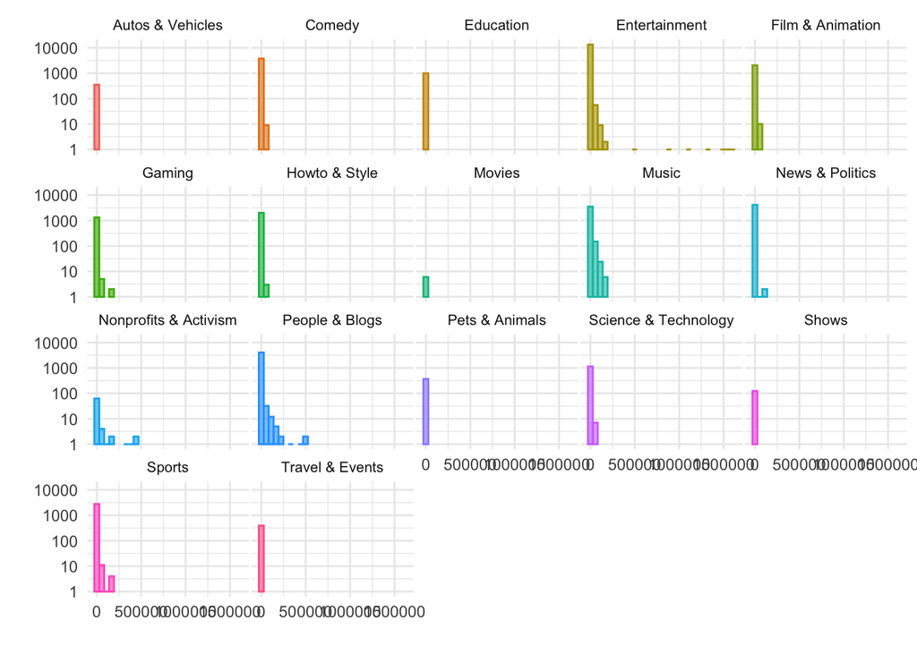

```r
df %>%
  ggplot(aes(x = dislikes, color = category_name, fill = category_name)) +
  geom_histogram(alpha = 0.6, bins = 30) +
  scale_y_continuous(trans = "log10") +
  theme_minimal() +
  theme(
    legend.position = "none",
    panel.spacing = unit(0.1, "lines"),
    strip.text.x = element_text(size = 8)
  ) +
  xlab("") +
  ylab("") +
  facet_wrap(~category_name)
```

The *Entertainment* category contains the largest population of dislikes, with *Comedy*, *Music*, *News & Politics*, and *People & Blogs* next most. This is a similar pattern between all three categories of Views, Likes, and Dislikes. This could suggest a **correlation** between these values. We will explore that later.

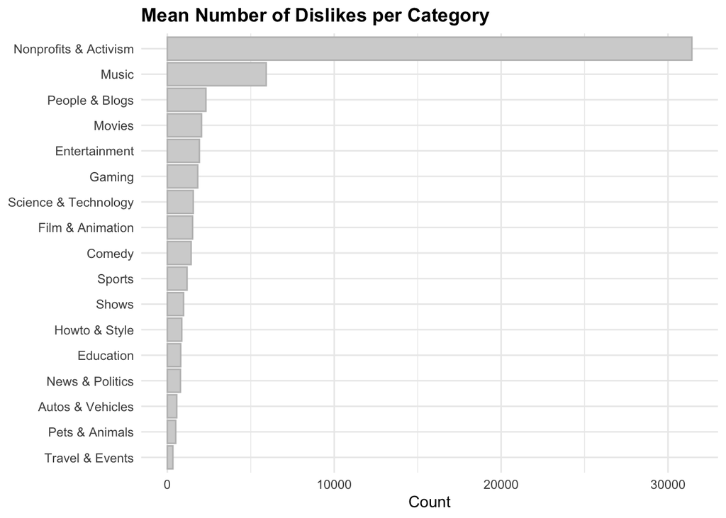

```r
df %>%
  group_by(category_name) %>%
  summarise(total_dislikes = mean(dislikes), .groups = "keep") %>%
  arrange(desc(total_dislikes)) %>%
  ggplot(aes(reorder(category_name, total_dislikes), total_dislikes)) +
  geom_col(color = "gray", fill = "lightgray") +
  theme_minimal() +
  theme(
    plot.title = element_text(face = "bold")
  ) +
  labs(
    x = NULL, y = "Count",
    title = "Mean Number of Dislikes per Category"
  ) +
  coord_flip()
```

For mean *Dislikes*, we can see that in this case, *Nonprofits & Activism* is the far and away leader.

Let’s explore a few of the top selections in this category.

```r
df %>%
  filter(category_name == "Nonprofits & Activism") %>%
  group_by(video_id, title) %>%
  summarise(dislikes = mean(dislikes)) %>%
  arrange(desc(dislikes)) %>%
  head()
```

| video_id | title | dislikes |
| --- | --- | --- |
| oWjxSkJpxFU | Suicide: Be Here Tomorrow. | 355483.6 |
| Tz50vEX0nwE | Объявляем забастовку избирателей | 139619.0 |
| BplJQtpfero | Об итогах забастовки и «выборов» | 64759.5 |
| 6dIjeUB51-s | Распаковка гаджета за 10 млрд рублей | 49832.0 |
| WA0Ek8RT20s | Кемерово: что случилось и кто виноват | 31931.0 |
| rbRoZyuOijk | Дворец, на который запрещено смотреть | 27572.0 |

The first video is a suicide prevention video by a Popular YouTuber who received backlash over inappropriate comments he made regarding Suicide in a prior video. Others are Russian news and finally some political videos.

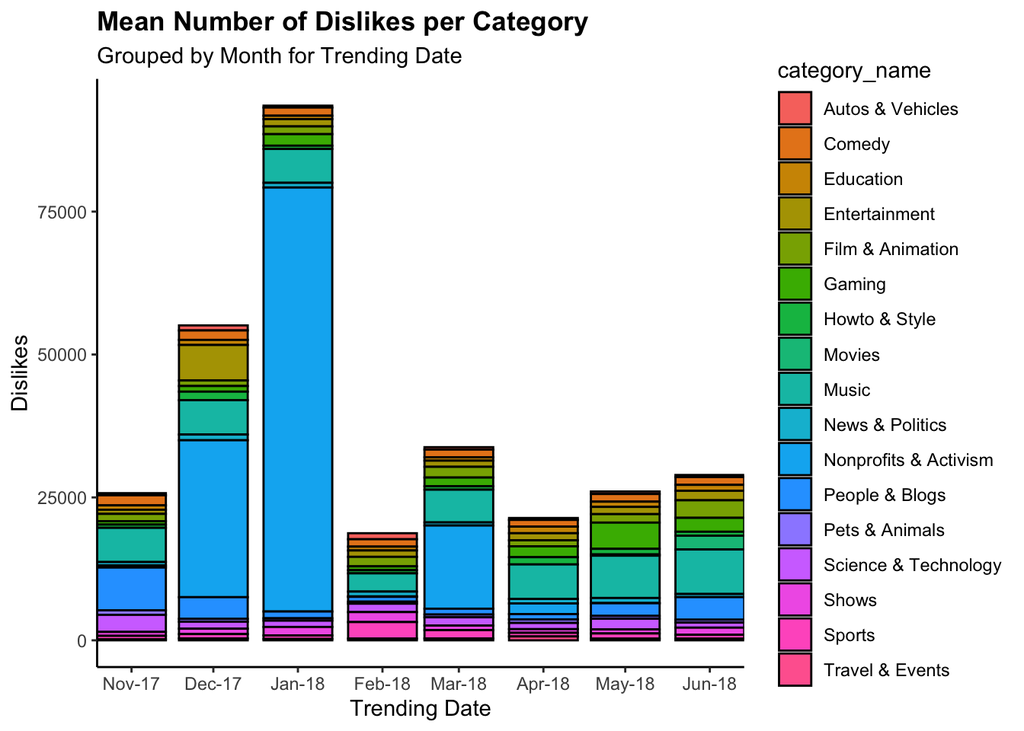

```r
df %>%
  mutate(mon = floor_date(trending_date, "month")) %>%
  group_by(mon, category_name) %>%
  summarize(total = mean(dislikes), .groups = "keep") %>%
  ggplot(aes(x = mon, y = total, fill = category_name)) +
  geom_col(color = "black") +
  scale_x_date(date_breaks = "1 month", expand = c(0, 0), date_labels = "%b-%y") +
  theme_classic() +
  theme(
    plot.title = element_text(face = "bold")
  ) +
  labs(
    x = "Trending Date", y = "Dislikes",
    title = "Mean Number of Dislikes per Category",
    subtitle = "Grouped by Month for Trending Date"
  )
```

There are two large spikes in December and January for *Nonprofits & Activism*. Overall, as demonstrated in the initial graph, dislikes are by volume lower than Likes, generally speaking.

## Top 5 Videos

- Identify the top 5 videos based on the number of views and number of likes

## Top 5 Videos based on Likes

The following are the top five videos based on *Likes*. We can see that the top 5 videos are all the same, but with different trending dates.

```r
df %>%
  arrange(desc(likes)) %>%
  select(trending_date, title, likes) %>%
  head(n = 5)
```

|  | trending_date | title | likes |
| --- | --- | --- | --- |
| 1 | 2018-05-23 | BTS (방탄소년단) 'FAKE LOVE' Official MV | 5053338 |
| 2 | 2018-05-22 | BTS (방탄소년단) 'FAKE LOVE' Official MV | 4924056 |
| 3 | 2018-05-21 | BTS (방탄소년단) 'FAKE LOVE' Official MV | 4750254 |
| 4 | 2018-05-20 | BTS (방탄소년단) 'FAKE LOVE' Official MV | 4470888 |
| 5 | 2018-05-19 | BTS (방탄소년단) 'FAKE LOVE' Official MV | 3880074 |

The following are the top five *unique* videos based on summ of all *likes* received.

```r
df %>%
  group_by(video_id, title) %>%
  summarise(likes = sum(likes), .groups = "keep") %>%
  arrange(desc(likes)) %>%
  head(n = 5)
```

| video_id | title | likes |
| --- | --- | --- |
| 7C2z4GqqS5E | BTS (방탄소년단) 'FAKE LOVE' Official MV | 23078610 |
| 6ZfuNTqbHE8 | Marvel Studios' Avengers: Infinity War Official Trailer | 18929848 |
| FlsCjmMhFmw | YouTube Rewind: The Shape of 2017 \| #YouTubeRewind | 16687951 |
| VYOjWnS4cMY | Childish Gambino - This Is America (Official Video) | 14593916 |
| xpVfcZ0ZcFM | Drake - God’s Plan | 12164958 |

### Top 5 Videos based on Views

The following are the top five unique videos based on *views*.

```r
df %>%
  group_by(video_id, title) %>%
  summarise(views = sum(views), .groups = "keep") %>%
  arrange(desc(views)) %>%
  head(n = 5)
```

| video_id | title | views |
| --- | --- | --- |
| FlsCjmMhFmw | YouTube Rewind: The Shape of 2017 \| #YouTubeRewind | 631428335 |
| 6ZfuNTqbHE8 | Marvel Studios' Avengers: Infinity War Official Trailer | 577553186 |
| VYOjWnS4cMY | Childish Gambino - This Is America (Official Video) | 411775069 |
| 7C2z4GqqS5E | BTS (방탄소년단) 'FAKE LOVE' Official MV | 321743622 |
| u9Mv98Gr5pY | VENOM - Official Trailer (HD) | 268913813 |

## Correlation to Likes

Earlier we observed that the distributions between *Views*, *Likes*, and *Dislikes* were all quite similar. Even after breaking them into categories, the shapes and sizes of the histograms per category were similar. We can explore how correlated they are. We’ll use “Likes” as the dependent variable.

```r
df_corr <- df %>%
  select_if(is.numeric) %>%
  # reordering the numeric columns so likes is listed first.
  select(likes, views, dislikes, comment_count)
```

## Correlation Test

In order to find out which numeric values correlate to likes, we can create a correlation matrix and correlation plot.

```r
corr <- round(cor(df_corr), 2)
corr
```

```
##               likes views dislikes comment_count
## likes          1.00  0.83     0.46          0.84
## views          0.83  1.00     0.56          0.69
## dislikes       0.46  0.56     1.00          0.64
## comment_count  0.84  0.69     0.64          1.00
```

We can see that all of the other numeric values positively correlate to *likes* with *comment_count* being the strongest at `0.84`, views being the next strongest at `0.83`, dislikes at `0.46`

Next we can see a visualization of these values.

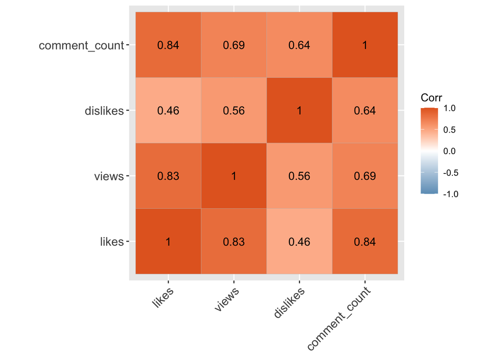

```r
ggcorrplot(corr, colors = c("#6D9EC1", "white", "#E46726"), lab = TRUE, ggtheme = ggplot2::theme_gray)
```

### Scatterplot

[figure not shown]

```r
df %>%
  ggplot(aes(x = likes, y = comment_count)) +
  geom_point(alpha = 0.1, color = "#E46726") +
  theme_minimal() +
  scale_x_continuous(trans = "log10") +
  scale_y_continuous(trans = "log10") +
  geom_smooth(method = "lm", se = TRUE, formula = y ~ x, color = "black", linetype = "dashed") +
  labs(
    x = "Views (Log 10 Scale)",
    y = "Likes (Log 10 Scale)",
    title = "Correlation of Comment Count vs. Views"
  )
```

After transforming the data on both axes with a log 10 scale, we can see the very linear, positive relationship between *Likes*’ dependent variable and our most robust correlated independent variable, *comment_count*.

Next, we’ll create a simple linear regression model and a multiple linear regression model and test which performs better.

```r
fit1 <- lm(formula = log1p(likes) ~ log1p(comment_count), data = df)

summary(fit1)
```

```
##
## Call:
## lm(formula = log1p(likes) ~ log1p(comment_count), data = df)
##
## Residuals:
##      Min       1Q   Median       3Q      Max
## -10.3344  -0.6043   0.0959   0.6852  10.1327
##
## Coefficients:
##                      Estimate Std. Error t value Pr(>|t|)
## (Intercept)          2.875172   0.023547   122.1   <2e-16 ***
## log1p(comment_count) 0.858186   0.003238   265.1   <2e-16 ***
## ---
## Signif. codes:  0 '***' 0.001 '**' 0.01 '*' 0.05 '.' 0.1 ' ' 1
##
## Residual standard error: 1.271 on 40879 degrees of freedom
## Multiple R-squared:  0.6322, Adjusted R-squared:  0.6322
## F-statistic: 7.026e+04 on 1 and 40879 DF,  p-value: < 2.2e-16
```

```r
fit2 <- lm(formula = log1p(likes) ~ log1p(views) + log1p(comment_count) + log1p(dislikes), data = df)

summary(fit2)
```

```
##
## Call:
## lm(formula = log1p(likes) ~ log1p(views) + log1p(comment_count) +
##     log1p(dislikes), data = df)
##
## Residuals:
##     Min      1Q  Median      3Q     Max
## -8.2157 -0.5824  0.1084  0.6662  5.0774
##
## Coefficients:
##                       Estimate Std. Error t value Pr(>|t|)
## (Intercept)          -0.235145   0.060428  -3.891 9.99e-05 ***
## log1p(views)          0.312152   0.006780  46.040  < 2e-16 ***
## log1p(comment_count)  0.415454   0.003919 106.017  < 2e-16 ***
## log1p(dislikes)       0.387105   0.005751  67.316  < 2e-16 ***
## ---
## Signif. codes:  0 '***' 0.001 '**' 0.01 '*' 0.05 '.' 0.1 ' ' 1
##
## Residual standard error: 1.019 on 40877 degrees of freedom
## Multiple R-squared:  0.7637, Adjusted R-squared:  0.7637
## F-statistic: 4.403e+04 on 3 and 40877 DF,  p-value: < 2.2e-16
```

```r
anova(fit1, fit2)
```

|  | Res.Df | RSS | Df | Sum of Sq | F | Pr(>F) |
| --- | --- | --- | --- | --- | --- | --- |
| 1 | 40879 | 66022.08 | NA | NA | NA | NA |
| 2 | 40877 | 42422.12 | 2 | 23599.95 | 11370.19 | 0 |

**Summary:** Both models are significant with very small P-values, and each independent variable in the multiple-regression model is also significant. When we perform an ANOVA test for significance, we can see that the Multiple Linear model (Fit2) still holds up and therefore is the better model increasing the Adjusted R-squared from `0.6322` to `0.7637`.

Therefore, with Model 2, we can say that for the dependent variable, *Likes*, *Views*, *Comment_Count*, and *Dislikes* contribute to `76.37%` of the variance.

# Text Analysis

The following sections will perform necessary preprocessing of the *title* field, and the *description* field and extract the top 35 most common words used.

## Titles

```r
title_corpus <- Corpus(VectorSource(df$title))
title_corpus
```

```
## <<SimpleCorpus>>
## Metadata:  corpus specific: 1, document level (indexed): 0
## Content:  documents: 40881
```

```r
inspect(title_corpus[1:4])
```

```
## <<SimpleCorpus>>
## Metadata:  corpus specific: 1, document level (indexed): 0
## Content:  documents: 4
##
## [1] Eminem - Walk On Water (Audio) ft. Beyoncé
## [2] PLUSH - Bad Unboxing Fan Mail
## [3] Racist Superman | Rudy Mancuso, King Bach & Lele Pons
## [4] I Dare You: GOING BALD!?
```

## Preprocessing

Using the `tm` package, perform transformations on the corpus to clean the text. There are generalized text cleaning activities such as normalization and stop word removal.

```r
# standard cleansing
title_corpus <- tm_map(title_corpus, tolower) # normalize case
title_corpus <- tm_map(title_corpus, removePunctuation) # remove punctuation
title_corpus <- tm_map(title_corpus, removeNumbers) # remove numbers
title_corpus <- tm_map(title_corpus, stripWhitespace) # remove white space
title_corpus <- tm_map(title_corpus, removeWords, stopwords("english")) # remove stopwords
inspect(title_corpus[1:4])
```

```
## <<SimpleCorpus>>
## Metadata:  corpus specific: 1, document level (indexed): 0
## Content:  documents: 4
##
## [1] eminem walk  water audio ft beyoncé
## [2] plush bad unboxing fan mail
## [3] racist superman rudy mancuso king bach lele pons
## [4]  dare  going bald
```

```r
# stem words using SnowBall stemmer
title_corpus <- tm_map(title_corpus, stemDocument)
```

## Document-Term Matrix

Create a `Term-Document Matrix` from the cleaned Corpus

```r
# The term document matrix is where each word/term is a row with documents as columns
title_dtm <- TermDocumentMatrix(title_corpus)

# inspect
inspect(title_dtm)
```

```
## <<TermDocumentMatrix (terms: 24539, documents: 40881)>>
## Non-/sparse entries: 250374/1002928485
## Sparsity           : 100%
## Maximal term length: 81
## Weighting          : term frequency (tf)
## Sample             :
##          Docs
## Terms     16041 16336 16821 17065 26967 27278 27487 28468 38427 39186
##   episod      0     0     0     0     0     0     0     0     0     0
##   full        1     1     1     1     1     1     0     0     1     1
##   game        0     0     0     0     0     0     0     0     0     0
##   music       0     0     0     0     0     0     0     0     0     0
##   new         0     0     0     0     0     0     0     0     0     0
##   offici      0     0     0     0     0     0     0     0     0     0
##   song        0     0     0     0     0     0     0     0     0     0
##   trailer     0     0     0     0     0     0     0     0     0     0
##   trump       0     0     0     0     0     0     0     0     0     0
##   video       0     0     0     0     0     0     0     0     0     0
```

```r
title_dtm1 <- removeSparseTerms(title_dtm, 0.99)
inspect(title_dtm1)
```

```
## <<TermDocumentMatrix (terms: 42, documents: 40881)>>
## Non-/sparse entries: 32830/1684172
## Sparsity           : 98%
## Maximal term length: 9
## Weighting          : term frequency (tf)
## Sample             :
##          Docs
## Terms     26359 28681 3874 4115 6112 6218 6342 6445 6701 6952
##   episod      0     0    0    0    0    0    0    0    0    0
##   full        2     1    1    1    1    1    1    1    1    1
##   game        0     0    0    0    0    0    0    0    0    0
##   music       0     1    1    1    1    1    0    1    1    0
##   new         1     1    1    1    1    1    1    1    1    1
##   offici      0     0    1    1    0    0    0    0    0    0
##   song        0     3    2    2    1    1    0    1    1    2
##   trailer     0     0    0    0    0    0    0    0    0    0
##   trump       0     0    0    0    0    0    0    0    0    0
##   video       0     0    0    0    1    1    0    1    1    1
```

## Perform Analysis

### Frequent Terms

- Use `freqwords()`: find frequent terms in a document-term or term-document matrix.
- Find terms that occur at least 5 times and show top 50

```r
findFreqTerms(title_dtm1, 5) %>%
  head(50)
```

```
##  [1] "music"     "offici"    "video"     "paul"      "new"       "final"
##  [7] "food"      "game"      "full"      "latest"    "punjabi"   "song"
## [13] "react"     "time"      "top"       "youtub"    "show"      "test"
## [19] "real"      "feat"      "tri"       "live"      "trump"     "season"
## [25] "break"     "best"      "trailer"   "episod"    "get"       "make"
## [31] "highlight" "part"      "life"      "day"       "first"     "movi"
## [37] "drama"     "challeng"  "nba"       "news"      "الحلقة"    "war"
```

```r
termCount <- rowSums(as.matrix(title_dtm1)) # sums rows
termCount <- subset(termCount, termCount >= 20)

title_df <- data.frame(term = names(termCount), freq = termCount)
```

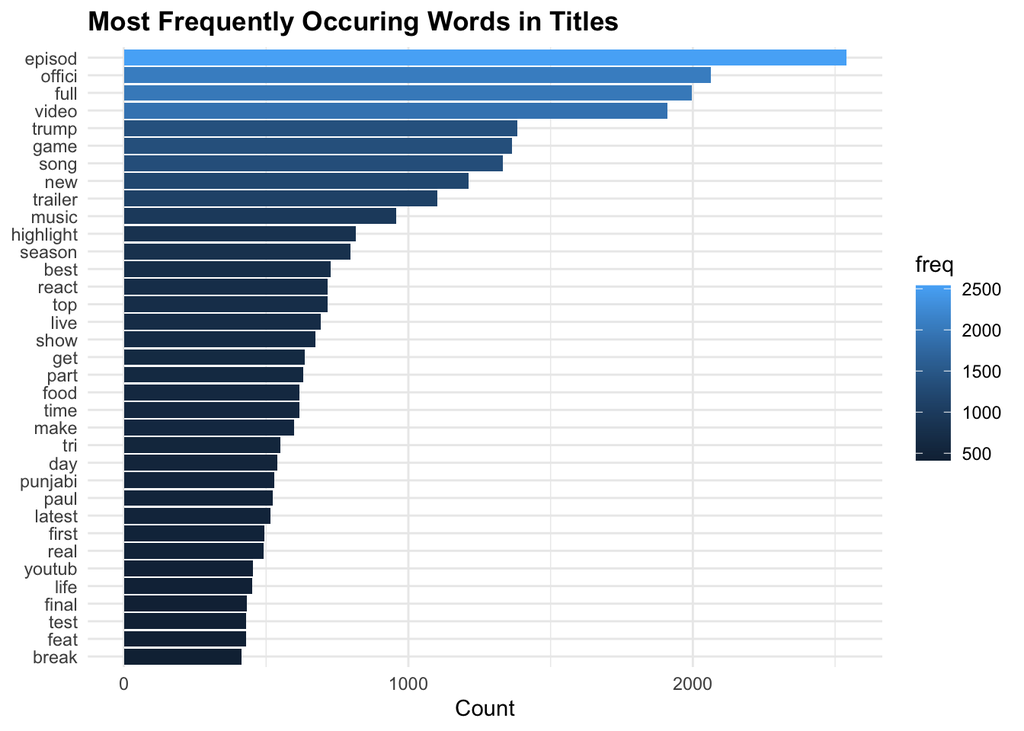

```r
title_df %>%
  head(35) %>%
  ggplot(aes(x = reorder(term, freq), y = freq, fill = freq)) +
  geom_bar(stat = "identity") +
  scale_colour_gradientn(colors = terrain.colors(10)) +
  theme_minimal() +
  coord_flip() +
  theme(
    plot.title = element_text(face = "bold")
  ) +
  labs(
    x = NULL, y = "Count",
    title = "Most Frequently Occuring Words in Titles"
  )
```

## Descriptions

```r
description_corpus <- Corpus(VectorSource(df$description))
description_corpus
```

```
## <<SimpleCorpus>>
## Metadata:  corpus specific: 1, document level (indexed): 0
## Content:  documents: 40881
```

```r
inspect(description_corpus[1:2])
```

```
## <<SimpleCorpus>>
## Metadata:  corpus specific: 1, document level (indexed): 0
## Content:  documents: 2
##
## [1] Eminem's new track Walk on Water ft. Beyoncé is available everywhere: http://shady.sr/WOWEminem \\nPlaylist Best of Eminem: https://goo.gl/AquNpo\\nSubscribe for more: https://goo.gl/DxCrDV\\n\\nFor more visit: \\nhttp://eminem.com\\nhttp://facebook.com/eminem\\nhttp://twitter.com/eminem\\nht…
## [2] STill got a lot of packages. Probably will last for another year. On a side note, more 2nd channel vids soon. editing with premiere from now on, gon' be a tedious transition, but i think it's for the best. \\n\\n__\\n\\nSUBSCRIBE ► http://www.youtube.com/subscription_center?add_user=iDubbbztv…
```

## Preprocessing

Using the `tm` package, perform transformations on the corpus to clean the text. There are generalized text cleaning activities such as normalization and stop word removal.

```r
# Remove URLs
description_corpus <- tm_map(
  description_corpus,
  content_transformer(function(x) gsub("http[[:alnum:][:punct:]]*", "", x))
)
# Replace new line symbols with a space
description_corpus <- tm_map(
  description_corpus,
  content_transformer(function(x) gsub("\\\\n", "", x))
)
# Remove non-ASCII characters in the dataset that people use to decorate text
description_corpus <- tm_map(
  description_corpus,
  content_transformer(function(x) iconv(x, "latin1", "ASCII", sub = ""))
)
inspect(description_corpus[1:4])
```

```
## <<SimpleCorpus>>
## Metadata:  corpus specific: 1, document level (indexed): 0
## Content:  documents: 4
##
## [1] Eminem's new track Walk on Water ft. Beyonc is available everywhere:  Playlist Best of Eminem:  for more:  more visit:  video by Eminem performing Walk On Water. (C) 2017 Aftermath Records
## [2] STill got a lot of packages. Probably will last for another year. On a side note, more 2nd channel vids soon. editing with premiere from now on, gon' be a tedious transition, but i think it's for the best. __SUBSCRIBE   Channel   Channel   Channel
## [3] WATCH MY PREVIOUS VIDEO  SUBSCRIBE   FOR WATCHING! LIKE & SUBSCRIBE FOR MORE VIDEOS!-----------------------------------------------------------FIND ME ON: Instagram |  |  |  Rudy Mancuso |  Pons |  Bach |  Effects: Caleb Natale |  GregoryShots Studios Channels:Alesso |  |  Jibawi |  Puppets |…
## [4] I know it's been a while since we did this show, but we're back with what might be the best episode yet!Leave your dares in the comment section! Order my book how to write good  Launched New Official Store Channel us mail or whatever you want here!PO Box 232355Las Vegas, NV 89105
```

```r
# standard cleansing
description_corpus <- tm_map(description_corpus, tolower) # normalize case
description_corpus <- tm_map(description_corpus, removePunctuation) # remove punctuation
description_corpus <- tm_map(description_corpus, removeNumbers) # remove numbers
description_corpus <- tm_map(description_corpus, stripWhitespace) # remove white space
description_corpus <- tm_map(description_corpus, removeWords, stopwords("english")) # remove stopwords
inspect(description_corpus[1:4])
```

```
## <<SimpleCorpus>>
## Metadata:  corpus specific: 1, document level (indexed): 0
## Content:  documents: 4
##
## [1] eminems new track walk  water ft beyonc  available everywhere playlist best  eminem    visit video  eminem performing walk  water c aftermath records
## [2] still got  lot  packages probably will last  another year   side note  nd channel vids soon editing  premiere  now  gon   tedious transition   think    best subscribe channel channel channel
## [3] watch  previous video subscribe  watching like subscribe   videosfind   instagram rudy mancuso pons bach effects caleb natale gregoryshots studios channelsalesso jibawi puppets stocking sarkis pons tyson rudy mancuso studios
## [4]  know     since    show   back   might   best episode yetleave  dares   comment section order  book   write good launched new official store channel us mail  whatever  want herepo box las vegas nv
```

```r
# Use the Snowball Stemmer on the Corpus
description_corpus <- tm_map(description_corpus, stemDocument)
```

## Document-Term Matrix

Create a `Term-Document Matrix` from the cleaned Corpus

```r
# The term document matrix is where each word/term is a row with documents as columns
description_dtm <- TermDocumentMatrix(description_corpus)

# inspect
inspect(description_dtm)
```

```
## <<TermDocumentMatrix (terms: 101708, documents: 40881)>>
## Non-/sparse entries: 1965755/4155958993
## Sparsity           : 100%
## Maximal term length: 1060
## Weighting          : term frequency (tf)
## Sample             :
##           Docs
## Terms      11818 12008 12206 12426 12663 26712 33087 35998 38860 39007
##   channel      0     0     0     0     0     0     0     0     0     0
##   facebook     0     0     0     0     0     0     0     0     0     0
##   get          0     0     0     0     0     3     0     0     0     0
##   music        0     0     0     0     0     0     0     4     3     3
##   new          0     0     0     0     0     2     0     2     3     3
##   show         0     0     0     0     0     0     0     3     3     3
##   subscrib     0     0     0     0     0     0     0     2     2     2
##   twitter      0     0     0     0     0     0     0     0     0     0
##   video        0     0     0     0     0     2     0     6     6     6
##   watch        1     1     1     1     1     2     0     0     0     0
```

```r
description_dtm1 <- removeSparseTerms(description_dtm, 0.95)
inspect(description_dtm1)
```

```
## <<TermDocumentMatrix (terms: 89, documents: 40881)>>
## Non-/sparse entries: 341346/3297063
## Sparsity           : 91%
## Maximal term length: 9
## Weighting          : term frequency (tf)
## Sample             :
##           Docs
## Terms      10007 10222 10487 16348 25683 33256 37170 37356 9596 9795
##   channel      0     0     0     3     0     0     2     2    0    0
##   facebook     1     1     1     0     0     0     0     0    1    1
##   get          0     0     0     0     0     0     7     7    0    0
##   music        0     0     0     0     0     5     4     4    0    0
##   new         49    49    49     0     0    25     0     0   49   49
##   show         1     1     1     1     0     0     1     1    1    1
##   subscrib     0     0     0     0     0     0     3     3    0    0
##   twitter      0     0     0     0     0     0     0     0    0    0
##   video        2     2     2     0    45     7     9     9    2    2
##   watch        3     3     3    26     0     0     2     2    3    3
```

### Frequent Terms

- Use `freqwords()`: find frequent terms in a document-term or term-document matrix.
- Find terms that occur at least 5 times and show top 50

```r
findFreqTerms(description_dtm1, 5) %>%
  head(50)
```

```
##  [1] "best"      "new"       "video"     "channel"   "now"       "subscrib"
##  [7] "will"      "year"      "instagram" "like"      "watch"     "back"
## [13] "box"       "comment"   "episod"    "know"      "offici"    "show"
## [19] "want"      "produc"    "thank"     "websit"    "also"      "facebook"
## [25] "follow"    "game"      "merch"     "music"     "news"      "twitter"
## [31] "use"       "youtub"    "enjoy"     "product"   "time"      "make"
## [37] "song"      "thing"     "can"       "join"      "life"      "live"
## [43] "one"       "day"       "much"      "pleas"     "help"      "peopl"
## [49] "link"      "love"
```

```r
termCount <- rowSums(as.matrix(description_dtm1)) # sums rows
termCount <- subset(termCount, termCount >= 20)

description_df <- data.frame(term = names(termCount), freq = termCount)
```

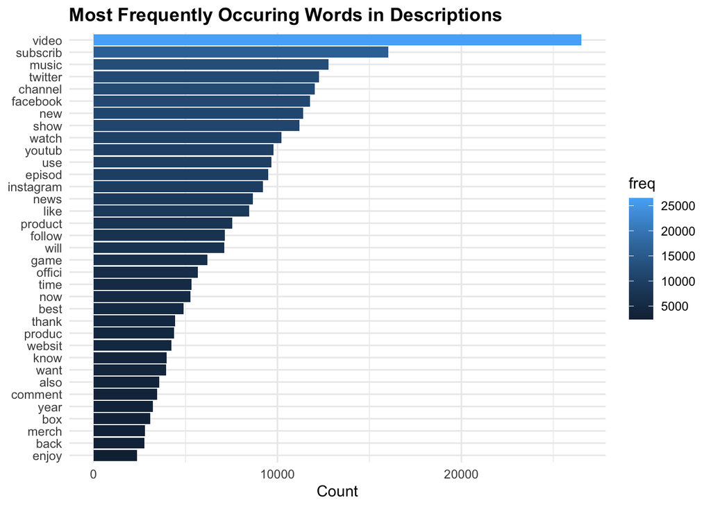

```r
description_df %>%
  head(35) %>%
  ggplot(aes(x = reorder(term, freq), y = freq, fill = freq)) +
  geom_bar(stat = "identity") +
  scale_colour_gradientn(colors = terrain.colors(10)) +
  theme_minimal() +
  coord_flip() +
  theme(
    plot.title = element_text(face = "bold")
  ) +
  labs(
    x = NULL, y = "Count",
    title = "Most Frequently Occuring Words in Descriptions"
  )
```